# Urban Analytics and City Science Assessment 2051924

2024-12-01

### **Introduction**

Social networks exist on a diverse scale, ranging from the interactions between individual people and places to communities, aggregated localities and countries. These social interactions take place in many forms and propagate across multiple dimensions (Bardis, 1979). One example that embodies such characteristics is Social Media; simultaneously abstract and digital but also a reflection of real world phenomena and lived social interactions. The analysis of social media networks therefore provides an opportunity to explore real social networks using readily available data. One such example is the Facebook Social Connectedness Index.

The Facebook Social Connectedness Index (SCI) is an aggregated, depersonalised metric that captures the general probability of a facebook friendship connection between nations or geographic subdivisions, derived from facebook user data. As Bailey et al., 2018 (see p. 261) argues, since facebook friendships are primarily grounded in real-world connections, this dataset provides a valuable insight into global connectivity across multiple scales. The dataset has been used widely, both as a predictor of other factors such as international trade (Bailey et al., 2020b), pandemic dispersion (Prusaczyk et al., 2021), and to determine predictors of SCI itself. It is the latter goal that forms the core of this study. There exists many such studies, examining a wide range of the socio-economic and political determinants of SCI (See Bailey et al., 2020a, Bailey et al., 2018, Gavriilidis, 2020). However, there is a noted lack of cultural and semantic explanations of SCI in the literature; despite a strong corpus of research to confirm their importance in human connection (See Geertz., 1973 for a concise overview)

One such example, Bailey et al., 2020c, examines language and religious similarity alongside other variables in predicting European SCI, but does not consider global connectedness. The aim of this paper therefore is to build upon this past research by investigating the validity and usefulness of language and religion to predict the connectivity of the global network of nations.

### Methodology

#### Data - analysis and transformations

As mentioned, the primary dataset used in this report is the Facebook Social Connectedness Index, provided on an open license basis by META (See Bailey et al., 2018). The data is provided in many forms of geographic scale; the broadest of these was chosen for this research project. Specifically, country pairings of SCI, as determined by the following equation:

$$SCI_{i,j} = \frac{\text{Facebook Connections}_{i,j}}{\text{Facebook
Users}_i \times \text{Facebook Users}_j}$$

Country pairings were chosen over more resolute datasets, including administrative subdivisions and US counties, to broaden the scope of the project and improve computational efficiency. Figure 1 below demonstrates the global network of country connections.

```r
# Import data
# Data was precomputed and imported to save computational cost
# See methodology for data construction
# Path names are hard coded as directory defaults to incorrect location
# Document does not knit using a file.path() or project root method

fb_cnt_sci <- read.table("C:/Users/nx21502/OneDrive - University of Bristol/Urban Analytics and City Science/assignment/countries-countries-fb-social-connectedness-index-october-2021.tsv", header = TRUE)   # facebook Social Connectedness Index

gdp_pc_sim <- read.csv("C:/Users/nx21502/OneDrive - University of Bristol/Urban Analytics and City Science/assignment/gdp_df.csv") # GDP per capita similarity determined through euclidean distance


religion_sim <- read.csv("C:/Users/nx21502/OneDrive - University of Bristol/Urban Analytics and City Science/assignment/religion_sim.csv")   #country religious similarity index determined through euclidean distance

language_cle <- read.csv("C:/Users/nx21502/OneDrive - University of Bristol/Urban Analytics and City Science/assignment/lang_cle.csv")  #Language Similarity - CEPII CLE index

# Geographic distance - calculated in methodology below

dist <- read.csv("C:/Users/nx21502/OneDrive - University of Bristol/Urban Analytics and City Science/assignment/geographic_dist.csv")

# Network Analysis Metrics
metrics_df <- read.csv("C:/Users/nx21502/OneDrive - University of Bristol/Urban Analytics and City Science/assignment/metrics_df.csv")

# Subset of 20 countries - Network Analysis Metrics
subset_metrics_df <- read.csv("C:/Users/nx21502/OneDrive - University of Bristol/Urban Analytics and City Science/assignment/metrics_df.csv")
```

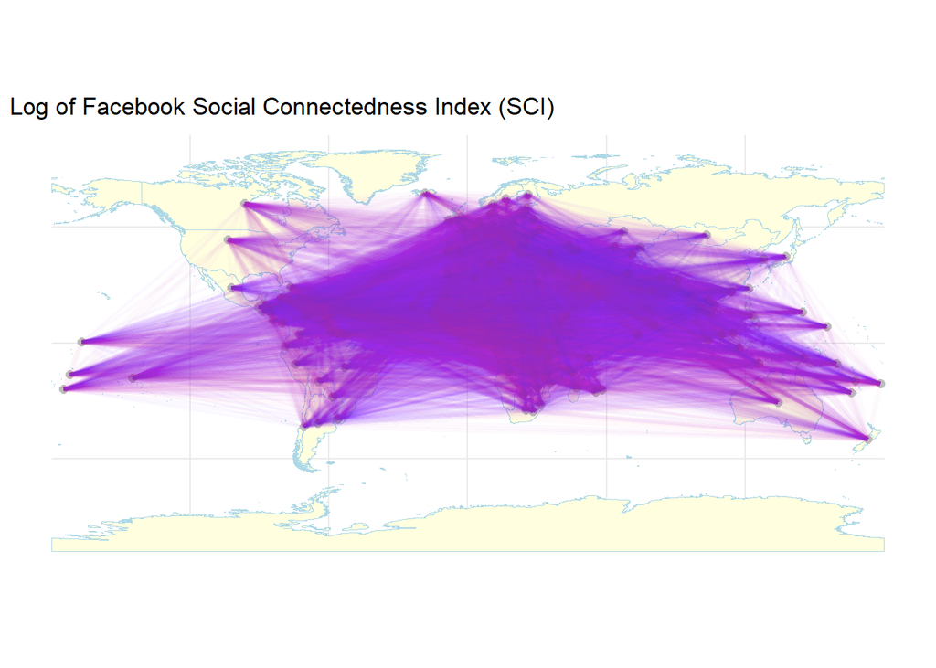

```r
# Plotting world map of SCI country-country connections:

# Downloading world map from GiTHUB
devtools::install_github("ropensci/rnaturalearthhires")

# Use ne_countries function to obtain world shapefile
world <- ne_countries(scale = "large", type = "countries", returnclass = "sf")

# Selecting only the two letter country code and geometry columns
world_trim <- world %>%
  select(iso_a2, geometry)

# Making geometries valid
world_trim_valid <- st_make_valid(world_trim)

# Calculating centroids of each country polygon
world_centroids <- st_centroid(world_trim_valid)

# Preparing the graph for plotting - create country coordinate data frame
country_coords <- as.data.frame(st_coordinates(world_centroids))

# Add ISO2 name column
country_coords$country <- world_centroids$iso_a2

# Standardizing names so that only centroids from countries in the SCI dataset are included (this should also avoid errors in inputting countrys as vertices?)

# Combine both columns into a single vector of country names
countries_in_network <- unique(c(fb_cnt_sci$user_loc, fb_cnt_sci$fr_loc))

# Filter the country_coords data to include only the countries present in the network
filtered_country_coords <- country_coords[country_coords$country %in% countries_in_network, ]

# Attempting to data wrangle missing country data - using setdiff() to identify missing coordinates
missing_in_coords <- setdiff(countries_in_network, filtered_country_coords$country)

# Manually add coordinates for missing countries
missing_coords <- data.frame(
  country = c("FR", "GF", "GP", "MQ", "RE", "YT", "TW", "XK", "NO"),
  X = c(2.2137, -53.125, -61.527, -61.024, 55.236, 45.228, 121.5654, 20.911, 10.7522),
  Y = c(46.6034, 3.9332, 16.265, 14.641, -21.115, -12.836, 23.6978, 42.6025, 59.9139)
)

# Add missing country coordinates to the filtered dataset
filtered_country_coords <- rbind(filtered_country_coords, missing_coords)

# Creating spatial object out of country coordinate dataframe
centroids_sf <- st_as_sf(filtered_country_coords, coords = c("X", "Y"), crs = 4326)

# Merging SCI data with centroids dataframe
connections_sf <- fb_cnt_sci %>%
  left_join(filtered_country_coords, by = c("user_loc" = "country")) %>%
  rename(lon1 = X, lat1 = Y) %>%
  left_join(filtered_country_coords, by = c("fr_loc" = "country")) %>%
  rename(lon2 = X, lat2 = Y)

# Drop NA values from connections dataframe
connections_sf <- connections_sf %>%
  drop_na()

# Add log of sclaed_sci to world connections dataset
connections_sf$scaled_sci_log <- log(connections_sf$scaled_sci + 1)


# Plot the world basemap
ggplot(data = world_trim) +
  geom_sf(fill = "lightyellow", color = "lightblue") +  # World map with countries
  geom_sf(data = centroids_sf, color = "grey", size = 2) +  # Centroids (dots)
  geom_segment(data = connections_sf, aes(x = lon1, y = lat1, xend = lon2, yend = lat2,
                                          color = scaled_sci_log, size = scaled_sci_log), alpha = 0.01, ) +
  scale_color_gradient(low = "blue", high = "red") +  # Color gradient for SCI
  scale_size_continuous(range = c(0.1, 2)) +  # Line thickness for SCI
  theme_minimal() +
  labs(title = "Log of Facebook Social Connectedness Index (SCI)",
       color = "SCI Value", size = "SCI Value") +
  theme(legend.position = "none",
        axis.text = element_blank(),
        axis.title = element_blank()
        )
```

*Figure 1: World Map of logged Facebook Social Connectedness Index for country pairs. Linewidth indicates connectedness, grey points denote country centroids*

To complement the data above, 3 other data sets were used in this analysis. To investigate the impacts of linguistic similarity on SCI, the ‘language’ data set provided by the Centre d’Etudes Prospectives et d’Informations Internationales (CEPII) was accessed under an open licence (See Melitz and Toubal, 2014). This data set includes a variety of aggregated metrics to estimate the language similarity between nations, the full extent of which may be seen at Melitz and Toubal, 2014. For this project, the common language index was extracted. To estimate the similarity of religious composition between nations, the ‘The Future of World Religions: Population Growth Projections, 2010-2050’ data, provided by the Pew Research Center, was imported (Pew Reserach Center, 2015). Data was filtered for 2020, to be most respective of the temporal scale of the SCI data, and then a similarity metric was calculated using the inverse of euclidean distance, as seen below.

```r
# Creating aggregated similarity metric for religion

r_countries <- religion_data$Country # Extracting country names
religion_data <- religion_data[,-1] # Removing name column
rownames(religion_data) <- r_countries # Setting country names as row names

# Data frame is ready, but was read in as character file so setting to be numeric
# Function below: removes < or > symbols for numeric conversion
religion_data[] <- lapply(religion_data, function(x) {
  # Replace occurrences of '> 99.0' with '99.5'
  x <- gsub(">99.0", "99.5", x)

  # Replace '< 1.0' values with '0.1'
  x <- gsub("< 1.0", "0.1", x)
  # Convert to numeric
  as.numeric(x)
})


# Calculate euclidean distance
dist_matrix <- dist(religion_data, method = "euclidean")

# Convert to similarity (1 / (1 + Euclidean distance))

similarity_matrix <- 1 / (1 + dist_matrix)

# Convert to matrix
similarity_matrix <- as.matrix(similarity_matrix)
```

```r
# Creating a euclidean distance based 'similarity metric' for gdp per capita as a control of socio-economic similarity

gdp_pc$gdp_pc <- as.numeric(gdp_pc$gdp_pc) # set to numeric

gdp_pc_clean <- gdp_pc %>% filter(!grepl("no data", gdp_pc, ignore.case = TRUE)) # remove 'no data' values

rownames(gdp_pc_clean) <- gdp_pc_clean$country # set rownames of dataset to country names

gdp_pc_clean <- select(gdp_pc_clean, "gdp_pc") # remove country column and retain gdp data
gdp_pc_clean$gdp_pc <- as.numeric(gdp_pc_clean$gdp_pc)

# scaling the data
gdp_scaled <- scale(gdp_pc_clean)

# Creating distance matrix
gdp_dist <- dist(gdp_pc_clean, method = "euclidean")

# Calculate similarity: 1 / (1 + distance)
gdp_similarity <- 1 / (1 + gdp_dist)
gdp_dist_matrix <- as.matrix(gdp_similarity)
```

Geographic distance is a proven control on country-country SCI (Bailey et al., 2018), and so was included in the analysis of this report to act as a control variable while investigating the impacts of language and religion on inter-country SCI. To create a geographic distance dataset, a shapefile of the world was downloaded using the rnaturalearth package (Massicote and South, 2024) and then the centroids of each country polygon inferred using the st_centroids function from the SF package (Pebesma, E. 2018). Following the manual interpolation of country centroids included in the SCI dataset, but missing in the world shapefile, an iterative loop was created to fill an empty matrix with country coordinates and then distances calculated using the distVincentysphere function from the geosphere package (Hijmans. RJ, 2018) to calculate the distances between. The resulting matrix was then transformed into a dataframe for use with other data.

```r
# Making geometries valid

world_trim_valid <- st_make_valid(world_trim)

# Calculating centroids of each country polygon
world_centroids <- st_centroid(world_trim_valid)


# Preparing the graph for plotting
country_coords <- as.data.frame(st_coordinates(world_centroids))
country_coords$country <- world_centroids$iso_a2

# Standardizing names so that only centroids from countries in the SCI dataset are included (this also avoids errors in inputting countrys as vertices)
# Combine both columns into a single vector of country names

countries_in_network <- unique(c(fb_cnt_cnt$user_loc, fb_cnt_cnt$fr_loc))

# Filter the country_coords data to include only the countries present in the network
filtered_country_coords <- country_coords[country_coords$country %in% countries_in_network, ]

# attempting to data wrangle country data and deduce missing centroids

missing_in_coords <- setdiff(countries_in_network, filtered_country_coords$country)



# Manually add coordinates for missing centroids
missing_coords <- data.frame(
  country = c("FR", "GF", "GP", "MQ", "RE", "YT", "TW", "XK", "NO"),
  X = c(2.2137, -53.125, -61.527, -61.024, 55.236, 45.228, 121.5654, 20.911, 10.7522),
  Y = c(46.6034, 3.9332, 16.265, 14.641, -21.115, -12.836, 23.6978, 42.6025, 59.9139)
)


# Add missing country coordinates to the filtered dataset
filtered_country_coords <- rbind(filtered_country_coords, missing_coords)

# Create a matrix to store distances
n <- nrow(spatial_df)
distance_matrix <- matrix(NA, nrow = n, ncol = n)

# Loop over all pairs of countries to calculate distances
for (i in 1:n) {
  for (j in 1:n) {
    # Get coordinates for country i and country j
    point_i <- c(spatial_df$X[i], spatial_df$Y[i])  # point_i as a vector (longitude, latitude)
    point_j <- c(spatial_df$X[j], spatial_df$Y[j])  # point_j as a vector (longitude, latitude)

    # Check if the points are being formed correctly
    print(paste("point_i:", point_i))
    print(paste("point_j:", point_j))

    # Calculate the distance using distVincentySphere
    distance_matrix[i, j] <- distVincentySphere(point_i, point_j)
  }
}

# Convert the distance matrix into a 3-column dataframe with country-country pairs and distances
distance_df <- data.frame(
  country1 = rep(spatial_df$country, each = n),
  country2 = rep(spatial_df$country, times = n),
  distance = as.vector(distance_matrix)
)

# Remove duplicate rows and then view for validity
distance_df <- distance_df[distance_df$country1 < distance_df$country2, ]

head(distance_df)

# Distance dataframe uses ISO2 so add country names using the country code package for ease of binding

distance_df$country1_name <- countrycode(distance_df$country1, "iso2c", "country.name")
distance_df$country2_name <- countrycode(distance_df$country2, "iso2c", "country.name")

# Distance matrix written to file using the code below and imported to save computational cost
#write.csv(distance_df, "geographic_dist.csv", row.names = FALSE)
```

#### Network Analysis and Community Detection

Network analysis methods were employed on the SCI dataset to investigate the characteristics and nature of the country relations. The SCI dataset is weighted and undirectional, therefore the following metrics were analyzed: Weighted Degree, Betweeness Centrality, Closeness Centrality and Eigenvector centrality. All of these were created using the igraph package (Csárdi et al., 2024), and then tabulated using the stargazer package (Hlavac M., 2022). For representation in this report, 20 countries were chosen based on their strategic importance in global affairs, and their contextual relationship with Religious and Linguistic international dynamics (See Fox., 2008 and Grimes., 1986). A full table of all country network metrics is included in the Appendix.

```r
# Create igraph object from SCI data
g <- graph_from_data_frame(fb_cnt_sci, directed = FALSE)
E(g)$weight <- fb_cnt_sci$scaled_sci # activate edges and weight as sci
```

```r
# Degree (weighted)
degree_weighted <- strength(g, mode = "all")

# Betweenness Centrality
betweenness_centrality <- betweenness(g, directed = FALSE)

# Closeness Centrality
closeness_centrality <- closeness(g, mode = "all")

# Eigenvector Centrality
eigenvector_centrality <- eigen_centrality(g)$vector



# Combine metrics into a data frame
metrics_df <- data.frame(
  Country = V(g)$name,
  Weighted_Degree = degree_weighted,
  Betweenness = betweenness_centrality,
  Closeness = closeness_centrality,
  Eigenvector = eigenvector_centrality,
)

# Write to file - code was precomputed using the above methodology and read in at the start of the document
#write.csv(metrics_df, "metrics_df.csv")


# Selecting subset of 20 countries:
# list of selected ISO2 country codes
selected_countries <- c("US", "AU", "IN", "GB", "BR", "CA", "DE", "ID",
                        "MX", "FR", "PK", "NG", "TR", "JP", "ZA", "EG",
                        "IT", "SA", "AR", "KR")

# Subset the dataset based on the country column (ISO2 code)
subset_df <- metrics_df[metrics_df$Country %in% selected_countries, ]

#add country names to the dataset and remove ISO2 codes
subset_df$Country <- countrycode(subset_df$Country, origin = "iso2c", destination = "country.name")

# Metrics calculated and saved to file, then imported for computational efficiency using following code

#write.csv(subset_df, "subset_metrics_df.csv")
```

To highlight the network characteristics of the data, a Louvain community detection algorithim was used to identify community groups within the data (See Blondel et al., 2008). This was method chosen due to its strength in detecting modular structures and capacity for working with weighted networks. Community detection and respective modularity score was calculated using the ‘cluster_louvain’ and ‘modularity’ functions from the igraph package.

```r
# Modularity (using Louvain method for community detection)
community_louvain <- cluster_louvain(g)
modularity_score <- modularity(community_louvain)
```

#### Regression Models

$$\log(\text{scaled_SCI}) = \beta_0 + \beta_1 \cdot
\text{religious_similarity} + \beta_2 \cdot \text{cle} + \beta_3 \cdot
\text{distance} + \beta_4 \cdot \text{GDP_pc_Similarity} + \epsilon$$

Due to methodological differences in the data, incomplete and missing values were present in all fields (excluding SCI). Therefore two aggregated datasets were used for regression analysis. One which excluded all country-country rows with missing values, and another that used K Nearest Neighbours (kNN) imputation. A random seed was set for reproducibility, and k was set as 5 to balance simplicity and validity. Interpolation was performed using the kNN function from the VIM package (Kowarik and Templ, 2016). Following this, 3 regression models were created. Two linear regression models using the aforely mentioned data, and then a Generalized Linear Model (GLM) using the imputed dataset. For the GLM, the Gamma family method was chosen as the log of scaled SCI values demonstrates a slight positive skew, therefore it was determined that a Gamma family regression would be worthwhile in highlighting potential relationships in the data, following examination and comparison with the other models.

```r
# Regression and Linear Modelling

# Preparing data for modelling

# Removing duplicate pairs from SCI data

fb_cnt_sci <- fb_cnt_sci[fb_cnt_sci$user_loc < fb_cnt_sci$fr_loc, ]


# Distance dataframe has names as ISO2, all other variables as full country name
# adding ISO2 to all for simplicity - fb data is ISO2

# Adding to GDP data

gdp_pc_sim$C1 <- countrycode(gdp_pc_sim$Country1, "country.name", "iso2c")
gdp_pc_sim$C2 <- countrycode(gdp_pc_sim$Country2, "country.name", "iso2c")

gdp_pc_sim <- gdp_pc_sim %>%
  select("C1", "C2", "Similarity")

# Adding to Language data


language_cle$C1 <- countrycode(language_cle$country_o, "country.name", "iso2c")
language_cle$C2 <- countrycode(language_cle$country_d, "country.name", "iso2c")

language_cle <- language_cle %>%
  select("C1", "C2", "cle")

# Adding to religion data

religion_sim$C1 <- countrycode(religion_sim$Country1, "country.name", "iso2c")
religion_sim$C2 <- countrycode(religion_sim$Country2, "country.name", "iso2c")

religion_sim <- religion_sim %>%
  select("C1", "C2", "Similarity")

# Renaming column names in distance & fb sci dataframes for simplicity of merging

colnames(dist) <- c("C1", "C2", "distance")
colnames(fb_cnt_sci) <- c("C1", "C2", "scaled_sci")
colnames(religion_sim) <- c("C1", "C2", "religious_similarity")
colnames(language_cle) <- c("C1", "C2", "cle")
colnames(gdp_pc_sim) <- c("C1", "C2", "GDP_pc_Similarity")
# Merging into one aggregated dataset


merged_df <- fb_cnt_sci %>%
  left_join(religion_sim, by = c("C1", "C2")) %>%
  left_join(language_cle, by = c("C1", "C2")) %>%
  left_join(dist, by = c("C1", "C2")) %>%
  left_join(gdp_pc_sim, by = c("C1", "C2"))


# Removing country name columns for imputing data

merged_df <- merged_df %>%
  select("scaled_sci", "religious_similarity", "cle", "GDP_pc_Similarity", "distance")

#merged_df <- as.numeric(merged_df)
# Imputing values for Na data for use in a regression model, k estimated at 5 to balance simplicity and model performance
set.seed(42) #setting seed for reproducability


merged_df_imputed <- VIM::kNN(merged_df, k = 5, trace = FALSE)  # k is the number of neighbors

# Creating data set with no NA values through inner_join() function

merged_df_inner <- religion_sim %>%
  inner_join(language_cle, by = c("C1", "C2")) %>%
  inner_join(dist, by = c("C1", "C2")) %>%
  inner_join(gdp_pc_sim, by = c("C1", "C2")) %>%
  inner_join(fb_cnt_sci, by = c("C1", "C2"))

# Inner join drops 6716 rows, in comparison to 'left joined' data

# Log SCI data in imputed and No NA dataset

merged_df_imputed$scaled_sci_log <- log(merged_df_imputed$scaled_sci + 1)  # Adding 1 to avoid log(0)

merged_df_inner$scaled_sci_log <- log(merged_df_inner$scaled_sci + 1)

# Creating regression models
# No NA linear regresssion model
sci_lm_nona <- lm(scaled_sci_log ~ religious_similarity + cle + distance + GDP_pc_Similarity, data = merged_df_inner)

# Imputed data linear regression model
sci_lm_imputed <- lm(scaled_sci_log ~ religious_similarity + cle + distance + GDP_pc_Similarity, data = merged_df_imputed)

# Generalised Linear Model with Gamma distribution and log link for SCI data

sci_glm_imputed_gamma <- glm(scaled_sci_log ~ religious_similarity + cle + distance + GDP_pc_Similarity,
                             data = merged_df_imputed,
                             family = Gamma(link = "log"))
```

### Results

#### Network Analysis

The network analysis metrics for 20 selected nations may be seen in Table 1 below.

```r
# Network Metrics - data read in to save computational cost of knitting

subset_metrics_df <- read.csv("C:/Users/nx21502/OneDrive - University of Bristol/Urban Analytics and City Science/assignment/subset_metrics_df.csv")

# Remove country name column
subset_metrics_df <- subset_metrics_df[,-1]

stargazer(
  subset_metrics_df,
  type = "text", # use html output for rmarkdown
  summary = FALSE,
  title = "Network Metrics for Country-Country Social Connectedness",
  digits = 3
)
```

```
##
## Network Metrics for Country-Country Social Connectedness
## ===================================================================
##       Country     Weighted_Degree Betweenness Closeness Eigenvector
## -------------------------------------------------------------------
## 1    Argentina       4,810,974         0       0.00002    0.00000
## 2    Australia       7,911,008         0       0.00001    0.00003
## 3      Brazil        1,958,640         3       0.00002    0.00000
## 4      Canada        5,633,432         0       0.00001    0.00001
## 5     Germany        4,871,318         0       0.00001    0.00001
## 6      Egypt         3,446,050         0       0.00002    0.00000
## 7      France        7,293,846         0       0.00002    0.00001
## 8  United Kingdom    5,926,736         0       0.00001    0.00002
## 9    Indonesia       1,712,588         8       0.00002    0.00000
## 10     India          957,206         29       0.00002    0.00001
## 11     Italy         5,949,264         0       0.00002    0.00001
## 12     Japan         1,852,378        31       0.00002    0.00000
## 13  South Korea      4,306,810         4       0.00002    0.00000
## 14     Mexico        1,410,424        12       0.00002    0.00000
## 15    Nigeria        5,634,058         0       0.00001    0.00001
## 16    Pakistan       3,577,766         0       0.00001    0.00000
## 17  Saudi Arabia     5,721,480         0       0.00001    0.00001
## 18     Turkey        2,704,468         0       0.00002    0.00000
## 19 United States     3,088,742         0       0.00001    0.00000
## 20  South Africa     8,909,020         0       0.00002    0.00001
## -------------------------------------------------------------------
```

*Table 1: Network metrics for a subset of 20 countries in the network*

These statistics provide a general overview country position and importance within the network, although to understand the relationship of countries to each other Louvian community detection is used. The communities identified by the algorithim are demonstrated in Figure 2 below

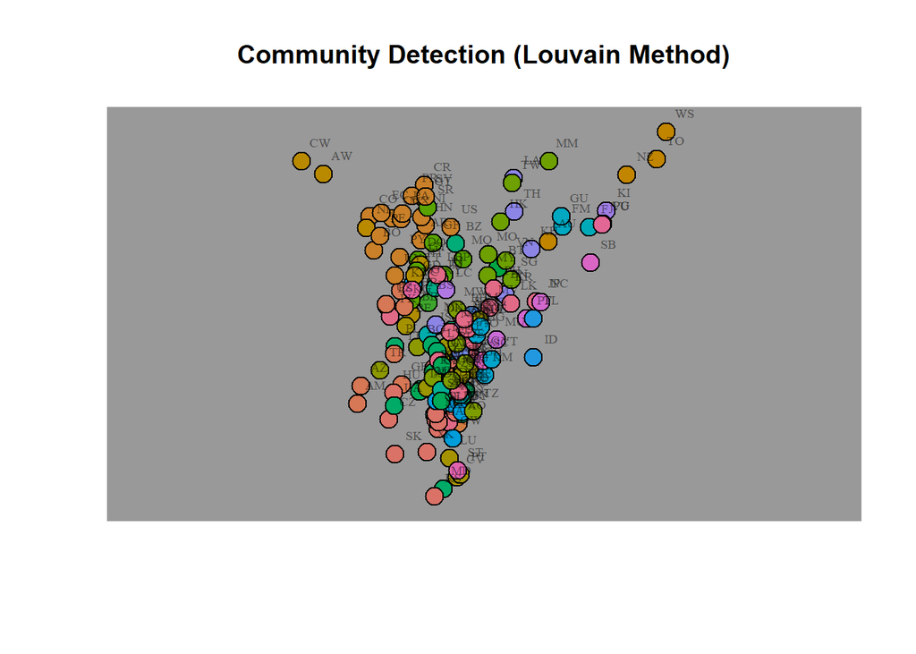

```r
# plotting community membership using louvain detection algorithm

# Create a custom color palette for communities
community_colors <- hcl.colors(length(unique(membership(community_louvain))), palette = "Dark3")


# Create a list of countries by community
communities_list <- split(V(g)$name, membership(community_louvain))

# Create a formatted legend description that includes countries
legend_descriptions <- sapply(1:length(communities_list), function(i) {
  paste("Community ", i, ": ", paste(communities_list[[i]], collapse = ", "), sep = "")
})


# Plot the network with improvements
plot(community_louvain, g,
     vertex.size=10,                   # points size
     vertex.label.cex=0.6,              # label size
     vertex.label.dist=2,               # Adjust label distance from points
     vertex.label.color=rgb(0, 0, 0, 0.5), # Slightly opaque label color (black with 50% opacity)
     edge.width=E(g)$weight / 10,       # Scale edge width based on weight
     edge.color=rgb(0.6, 0.6, 0.6),    # Lighter edge color for better visibility
     main="Community Detection (Louvain Method)",
     col=community_colors[membership(community_louvain)], # Color communities differently
     frame = FALSE,                     # Remove the default frame around the plot
     layout=layout_with_fr)             # Force-directed layout
```

*Figure 2: Abstract graph of community membership for countries in the SCI dataset, determined by Louvain community detection. Colour denotes community membership and countries are labelled by ISO2 code*

```r
# Modularity score
modularity_score <- modularity(community_louvain) #0.9297101

# Print modularity score
cat("The modularity score was determined as:", modularity_score, "\n")
```

```
## The modularity score was determined as: 0.9299283
```

The community data plotted above is represented for all nations in the map below:

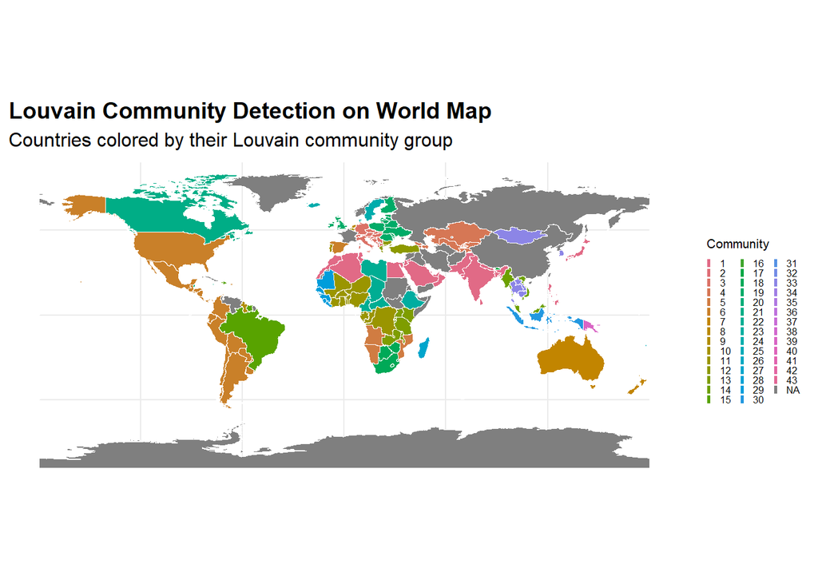

```r
# Using world shapefile downloaded previously, from rnaturalearthpackage

# Create a data frame for community memberships
community_membership <- membership(community_louvain)

# Create a data frame of country names and their corresponding community
community_df <- data.frame(Country = names(community_membership),
                           Community = community_membership)

# Merging with world map shapefile data
world_with_community <- world %>%
  left_join(community_df, by = c("iso_a2" = "Country"))

# Plotting community groups with ggplot2

ggplot(data = world_with_community) +
  geom_sf(aes(fill = factor(Community)), color = "white", size = 0.2) +
  scale_fill_manual(values = community_colors, name = "Community") +  # Use community colors
  theme_minimal() +
  theme(legend.position = "right") +  # Position legend at the bottom
  labs(title = "Louvain Community Detection on World Map",
       subtitle = "Countries colored by their Louvain community group") +
  theme(legend.title = element_text(size = 8),
        legend.text = element_text(size = 6),
        legend.key.size = unit(0.1, "cm"),
        plot.title = element_text(size = 14, face = "bold"),
        plot.subtitle = element_text(size = 12))
```

*Figure 3: World map of countries by community membership*

Figure 3 demonstrates the Louvain communities, projected onto cartographic space. The figure highlights the impacts of geographic and cultural proximity, as most communities share a geographic border and exist within the same general locality, exhibiting similar features. Some communities do not follow this trend, such as community number 43, which includes both India and Morocco; objectively geographically and culturally dissimilar nations but closely connected on Facebook. There are examples of clusters containing geographically distant nations with similar religious profiles: such as community number 33, containing buddhist majority Thailand and Mongolia. These open and differing explanations for community membership highlight the need for further analysis.

#### Linear regression

The specific impacts of the predictor variables were assessed through regression modelling. Linear regression modelling was performed on the assumption that the distribution of SCI is normal. The results of two linear regression models are seen collated below: the first of which was created using only complete data and the second includes imputed values where NA values were present.

```r
# Models created previously

# pass models to stargazer
stargazer(sci_lm_nona, sci_lm_imputed,
          type = "text",
          title = "OLS Regression Results",
          style = "all",
          align = FALSE)
```

```
##
## OLS Regression Results
## ======================================================================================================
##                                                     Dependent variable:
##                      ---------------------------------------------------------------------------------
##                                                       scaled_sci_log
##                                        (1)                                      (2)
## ------------------------------------------------------------------------------------------------------
## religious_similarity                  0.359*                                  0.517***
##                                      (0.200)                                  (0.162)
##                                     t = 1.792                                t = 3.188
##                                     p = 0.074                                p = 0.002
## cle                                  3.168***                                 3.191***
##                                      (0.096)                                  (0.089)
##                                     t = 33.046                               t = 36.043
##                                     p = 0.000                                p = 0.000
## distance                           -0.00000***                              -0.00000***
##                                      (0.000)                                  (0.000)
##                                    t = -58.168                              t = -73.948
##                                     p = 0.000                                p = 0.000
## GDP_pc_Similarity                    0.385***                                 0.379***
##                                      (0.056)                                  (0.048)
##                                     t = 6.813                                t = 7.933
##                                     p = 0.000                                p = 0.000
## Constant                             8.230***                                 8.298***
##                                      (0.049)                                  (0.040)
##                                    t = 168.684                              t = 206.103
##                                     p = 0.000                                p = 0.000
## ------------------------------------------------------------------------------------------------------
## Observations                          10,489                                   17,205
## R2                                    0.340                                    0.309
## Adjusted R2                           0.340                                    0.309
## Residual Std. Error             1.419 (df = 10484)                       1.477 (df = 17200)
## F Statistic          1,352.253*** (df = 4; 10484) (p = 0.000) 1,921.368*** (df = 4; 17200) (p = 0.000)
## ======================================================================================================
## Note:                                                                      *p<0.1; **p<0.05; ***p<0.01
```

*Table 2: Regression Outputs for Two Linear models evaluating the log of scaled SCI against predictor values*

```r
# pass GLM to stargazer
stargazer(sci_glm_imputed_gamma,
          type = "text",
          title = "Regression Results",
          style = "all",
          align = FALSE)
```

```
##
## Regression Results
## ================================================
##                          Dependent variable:
##                      ---------------------------
##                            scaled_sci_log
## ------------------------------------------------
## religious_similarity          0.071***
##                                (0.021)
##                               t = 3.316
##                               p = 0.001
## cle                           0.386***
##                                (0.012)
##                              t = 33.151
##                               p = 0.000
## distance                     -0.00000***
##                                (0.000)
##                              t = -72.184
##                               p = 0.000
## GDP_pc_Similarity             0.041***
##                                (0.006)
##                               t = 6.460
##                               p = 0.000
## Constant                      2.116***
##                                (0.005)
##                              t = 400.134
##                               p = 0.000
## ------------------------------------------------
## Observations                   17,205
## Log Likelihood               -29,925.570
## Akaike Inf. Crit.            59,861.140
## Residual Deviance       618.266 (df = 17200)
## Null Deviance           901.575 (df = 17204)
## ================================================
## Note:                *p<0.1; **p<0.05; ***p<0.01
```

*Table 3: GLM regression output*

### Discussion

#### Network Analysis

It is with this in mind that the betweenness centrality measures should be considered. Given that the SCI data is for all possible country-country pairs, betweenness centrality should be null for all (see Barrat et al., 2004). However, upon consideration of the varying levels of connectedness for each nation, and negligible or non-existent SCI values, countries with counts of betweenness centrality may be assumed as common ground between nations that do not connect. To highlight this, many of the nations with high betweenness possess large populations and economies whilst being located in Asia or less economically developed nations, such as India and Mexico. This may suggest that these nations act as a bridge between their primary community of connectivity, and other nations which do not interact with the wider global network. Given that the majority of Betweenness values are zero, it is assumed only a few countries act as such bridges. If this is so, then it would imply that the network is highly fragmented with a handful of countries dominating interaction between self contained clusters.

The values for Closeness and Eigenvector centrality (See Table 1 and A1) are extremely small and demonstrate little variation. Given that the SCI dataset is nearly completely symmetrical and possesses most possible country pairs, this is to be expected and confirms the known structure of the data, however this does not imply that all countries are equally connected, as is disproved by weighted degree.

This initial network analysis confirms that connectivity is not equal between nations and that religion and language may serve to explain a proportion of this variance.

#### Community Detection

Similar to the findings above, community detection analysis highlights the stratification of country connectedness. This is shown in Figure 2 and 3. In these, the importance of geographic proximity and linguistic similarity are apparent. This is best demonstrated by clusters 6 which comprises the majority of Spanish speaking Latin America.

The figures also highlight isolated communities, such as those comprising of only one or two nations, it is possible that these nations are isolated due to linguistic and cultural values, or for broader geopolitical reasons. Further analysis is required to determine the driving force of these communities.

#### Regression Modelling

The regression modelling, shown in tables 2 and 3, confirms the importance of the predictor variables included with the model and assumed from community detection. Given the larger variance and smaller coefficient values of the GLM, key findings will be taken from the linear regression model and it is assumed that a Gamma family GLM is not more useful in predicting the log of SCI due to the fairly normal distribution following a log transformation, and that the linear regression models are adequately robust to derive conclusions from.

In these models, language similarity shows a strong and highly significant positive relationship with SCI ( p <0.01), and has the largest coefficient of all variables. This confounds its importance to SCI as suggested by Bailey et al., 2020c. Religious similarity is also found to be statistically significant, although only to a p < 0.10 significance level in the data set that excludes NA values. This may suggest that the effect of religious similarity is more subtle than language and requires a larger data set to highlight this nuance, although it is logical that religious similarity between countries will have a positive impact of connectedness .(See Schwarz and Lynch, 2016). in the models, both of these predictor variables demonstrate a usefulness in predicting SCI and therefore confirms that Religion and Language are important drivers of international connectedness.

The findings from the models suggest therefore, that religious, linguistic and socio-economic activity are strong predictors of social connectedness at the country level. From this, with regard to the goal of this study, we assume that language and religion can be used, alongside other variables, to explain the connectedness of countries and play an important role in determining SCI.

#### Further research

More generally, research may build upon this study by increasing the granularity and scope of SCI connections. At the most detailed scale, the SCI data set is available for US - County to County or global adminsitrative subdivision connectedness. This may be further refined by investigating one or a few case studies of specific nations and regions to increase the understanding of drivers behind social connectedness.

Lastly, further research may include a wider range of predictor variables. to explore determinants of SCI. For example Bailey et al., 2018, included mutliple political and demography variables, all of which were found statistically significant at p < 0.01. Additionally, further research into the impacts of language and religion may wish to use unaggregated data, and consider specific religious groups or languages.

### Conclusion

This study has investigated the efficacy and validity of religion and language as controls on the connectedness of nations. The primary data source used to estimate the connectedness of nations was the SCI provided by Meta. This data source was firstly investigated from a network analysis perspective, highlighting the symmetrical structure of the dataset, the large variation in individual country connectedness, and the stratification of country communities on a global scale. To explore this last point in greater detail, community analysis was then undertaken to identify sub-sections of the network that are highly connected within their own ‘social sphere’, but with less connections elsewhere. To explain possible controls on these country communities, regression modelling was performed using a combination of cultural (Language and Religion similarity) and control variables (Geographic distance and GDP per capita similarity). Regression analysis highlighted the importance of linguistic similarity as a key determinant of country connectedness, and strongly suggested the importance of religious similarity. However, given possible methodological flaws in the design of this study, as described in the further research section, more work is needed to truly validate the importance of these. Further research investigating the importance of religion and language in influencing the connectedness between nations may wish to refine the methods of this study, potentially addressing the limitations highlighted above, to further investigate the role of language and religion in shaping global connectedness. Additionally, the exploration of other cultural and political factors may improve understanding of the driving forces behind international connections in the digital sphere.

Word Count = 3486

### Bibliography

Bailey, M., Cao, R., Kuchler, T., Stroebel, J. and Wong, A. (2018). Social Connectedness: Measurement, Determinants, and Effects. *Journal of Economic Perspectives*, [online] 32(3), pp.259–280. doi:https://doi.org/10.1257/jep.32.3.259.

Bailey, M., Farrell, P., Kuchler, T. and Stroebel, J. (2020a). Social connectedness in urban areas. *Journal of Urban Economics*, 118, p.103264. doi:https://doi.org/10.1016/j.jue.2020.103264.

Bailey, M., Gupta, A., Hillenbrand, S., Kuchler, T., Richmond, R. and Stroebel, J. (2020b). International Trade and Social Connectedness. *SSRN Electronic Journal*. doi:https://doi.org/10.2139/ssrn.3593163.

Bailey, M., Johnston, D., Kuchler, T., Russel, D., State, B. and Stroebel, J. (2020c). The Determinants of Social Connectedness in Europe. *Lecture Notes in Computer Science*, pp.1–14. doi:https://doi.org/10.1007/978-3-030-60975-7_1.

Bardis, P.D. (1979). Social Interaction and Social Processes. *Social Science*, [online] 54(3), pp.147–167. Available at: https://www.jstor.org/stable/41886414.

Barrat, A., Barthelemy, M., Pastor-Satorras, R. and Vespignani, A. (2004). The architecture of complex weighted networks. *Proceedings of the National Academy of Sciences*, 101(11), pp.3747–3752. doi:https://doi.org/10.1073/pnas.0400087101.

Blondel, V.D., Guillaume, J.-L., Lambiotte, R. and Lefebvre, E. (2008). Fast unfolding of communities in large networks. *Journal of Statistical Mechanics: Theory and Experiment*, 2008(10), p.P10008. doi:https://doi.org/10.1088/1742-5468/2008/10/p10008.

Bright, W. (1986). Ethnologue: Languages of the world Ed. by Barbara F. Grimes, and: Index to the Tenth edition of Ethnologue: Languages of the world Ed. by Barbara F. Grimes. *Language*, 62(3), pp.698–698. doi:https://doi.org/10.1353/lan.1986.0027.

Csárdi G, Nepusz T, Traag V, Horvát S, Zanini F, Noom D, Müller K (2024). *igraph: Network Analysis and Visualization in R*. doi:10.5281/zenodo.7682609, R package version 2.1.1, https://CRAN.R-project.org/package=igraph.

Fox, J. (2008). *A world survey of religion and the state*. Cambridge ; New York: Cambridge University Press.

Gavriilidis, K. (2020). Social connectedness and tourism demand. *Current Issues in Tourism*, pp.1–5. doi:https://doi.org/10.1080/13683500.2020.1803222.

Geertz, C. (1973). *The Interpretation of Cultures*. New York: Basic Books, p.5.

Hijmans, R.J. (2024) *geosphere: Spherical Trigonometry*. R package version 1.5-20. Available at: https://github.com/rspatial/geosphere

Hlavac M (2022). *stargazer: Well-Formatted Regression and Summary Statistics Tables*. Social Policy Institute, Bratislava, Slovakia. R package version 5.2.3, https://CRAN.R-project.org/package=stargazer.

International Monetary Fund (2021). *World Economic Outlook, October 2021 Recovery During a Pandemic*. [online] International Monetary Fund. Available at: https://www.imf.org/en/Publications/WEO/Issues/2021/10/12/world-economic-outlook-october-2021.

Kowarik, A. and Templ, M. (2016). Imputation with the R Package VIM. *Journal of Statistical Software*, 74(7). doi:https://doi.org/10.18637/jss.v074.i07.

Massicotte, P. and South, A. (2024) *rnaturalearth: World Map Data from Natural Earth*. R package version 1.0.1.9000. Available at: https://docs.ropensci.org/rnaturalearth/

Melitz, J. and Toubal, F. (2014). Native language, spoken language, translation and trade. *Journal of International Economics*, 93(2), pp.351–363. doi:https://doi.org/10.1016/j.jinteco.2014.04.004.

Pebesma, E. (2018). Simple Features for R: Standardized Support for Spatial Vector Data. *The R Journal*, 10(1), p.439. doi:https://doi.org/10.32614/rj-2018-009.

PEW RESEARCH CENTRE (2015). The Future of World Religions: Population Growth Projections, 2010-2050. [online] Available at: https://www.pewresearch.org/religion/2015/04/02/religious-projections-2010-2050/.

Prusaczyk, B., Pietka, K., Landman, J.M. and Luke, D.A. (2021). Utility of Facebook’s Social Connectedness Index in Modeling COVID-19 Spread: Exponential Random Graph Modeling Study. *JMIR Public Health and Surveillance*, 7(12), p.e33617. doi:https://doi.org/10.2196/33617.

Schwarz, T.B. and Lynch, C. (2016). Religion in International Relations. *Oxford Research Encyclopedia of Politics*. doi:https://doi.org/10.1093/acrefore/9780190228637.013.122.

### Appendix

Table A1

```r
# Plotting Table of all country network values

# Remove country name column
metrics_df_trim <- metrics_df[,-1]

stargazer(
  metrics_df_trim,
  type = "text",
  summary = FALSE,
  title = "Network Metrics for Country-Country Social Connectedness",
  digits = 3
)
```

```
##
## Network Metrics for Country-Country Social Connectedness
## =============================================================
##     Country Weighted_Degree Betweenness Closeness Eigenvector
## -------------------------------------------------------------
## 1     AE       9,230,584         0       0.00001    0.0001
## 2     AG     1,786,731,690       0       0.00002    0.0003
## 3     AL      35,066,402         0       0.00002    0.00000
## 4     AM      32,570,496      406.619    0.00003    0.00000
## 5     AO      43,123,546         0       0.00002    0.00000
## 6     AR       4,810,974         0       0.00002    0.00000
## 7     AT      21,077,388         0       0.00002    0.00001
## 8     AU       7,911,008         0       0.00001    0.00003
## 9     AW      898,424,422        0       0.00002    0.00001
## 10    AZ      16,083,740         0       0.00002    0.00000
```

[output cut: 176 more lines]

*Table A1: Network metrics for all countries in the SCI database*